# Labor Market Analysis

Exploratory Data Analysis

Marjorie Blanco, Joe Thomson, Haodi Tu

## Data

We used data from the 2016 ACS for Puerto Rico to examine earnings gaps between individuals with different education levels. Our research questions are: 1) How do earnings vary by education level? 2) How does the premium for education vary by gender? The 2016 ACS is a nationally representative sample of 30224. The household survey includes questions pertaining to each household member’s demographic characteristics and labor market activity.

We restrict our sample to these three racial groups: White, Black and Other. In addition, given our goal of examining earnings differences by ability to speak English and the reporting of earnings in the ACS on an annual basis (wages, salary, commissions, bonuses, tips, and self-employment income during the past 12 months), we restrict our sample to full-time year-round (FTYR) workers. We define FTYR workers as individuals who report positive earnings over the past year, who worked at least 40 of the past 52 weeks, and who worked at least 35 hours per week in a usual work week over this period.

## EDA Insights:

For our exploratory analysis we looked at population breakdowns by education, age, marital status, gender, race, earnings, and work hours. We applied filters on education (HS diploma or above), age (18-64), work weeks (> 40 weeks) and work hours (>35 hours/week).

An earnings histogram identified a default maximum amount of earnings (189k) which we also filtered out of the data. The wage distribution is progressive above the median, but drops off sharply below the median, likely indicating the presence of a minimum wage. The correlation between age and earnings is very weak (.23). Likewise, earnings is very weakly correlated with hours worked among those who work more than 35 hours per week. However, white individuals appear to have an earnings premium over other races, and both married and divorced individuals appear to have an earnings premium over those who have never been married. Given that the correlation between age and earnings was weak, this may be due to other qualitative factors possessed by those who get married. Married was recategoried to married and not married.

Earnings appear positively correlated with how well people speak English, as well as with higher levels of education. It should be noted that, on the island, fluency in the English language is neither a requirement, nor really needed. As a Latin American destination, the predominant language spoken and used (e.g. street signs, day-to-day communications) is Spanish, with English only coming into use in the tourism industry, or in those industies or companies imported from the mainland. This may help to explain the wage difference, as those are likely to pay more than local businesses (note that tourism is the largest industry on the island and the source of most of the island’s GDP). Men also appear to earn a small premium over women.

The age distribution of full time workers is skewed towards older adults, possibly indicating that younger workers have trouble finding full-time work, wait to enter the workforce, or are leaving the territory.

## Task 1:

Examine the first 10 or 20 observations (rows of data) corresponding to variables of interest (columns) and compare the observed values to the data dictionary for person records.

| ID | WAGP | SEX | AGEP | RAC1P | RACWHT | RACBLK | HISP | MAR |
| --- | --- | --- | --- | --- | --- | --- | --- | --- |
| 10 | 34000 | 1 | 47 | White | Yes | No | 03 | Married |
| 20 | 13000 | 1 | 58 | Black or African American | No | Yes | 03 | Never married |
| 43 | 18000 | 1 | 50 | White | Yes | No | 03 | Married |
| 44 | 10300 | 2 | 39 | White | Yes | No | 03 | Married |
| 49 | 28600 | 2 | 39 | Black or African American | No | Yes | 03 | Married |
| 50 | 24800 | 1 | 37 | Black or African American | No | Yes | 05 | Married |
| 53 | 22000 | 2 | 47 | Some Other | No | No | 03 | Never married |
| 58 | 19000 | 2 | 60 | Black or African American | No | Yes | 03 | Never married |
| 61 | 87000 | 2 | 58 | White | Yes | No | 03 | Divorced |
| 62 | 8000 | 1 | 33 | White | Yes | No | 03 | Never married |
| 64 | 22900 | 1 | 61 | White | Yes | No | 03 | Divorced |
| 70 | 19000 | 1 | 39 | Black or African American | No | Yes | 03 | Married |
| 71 | 19600 | 2 | 36 | Black or African American | No | Yes | 03 | Married |
| 74 | 48000 | 1 | 30 | Two or More Races | Yes | Yes | 03 | Divorced |
| 77 | 40000 | 2 | 30 | White | Yes | No | 03 | Never married |
| 78 | 15600 | 2 | 41 | White | Yes | No | 03 | Never married |
| 82 | 12100 | 1 | 46 | White | Yes | No | 03 | Divorced |
| 85 | 14000 | 1 | 53 | White | Yes | No | 03 | Married |
| 94 | 80000 | 1 | 38 | White | Yes | No | 03 | Never married |
| 108 | 15100 | 2 | 26 | Some Other | No | No | 03 | Never married |

| ID | SCHL | ENG | COW | WKW | WKHP |
| --- | --- | --- | --- | --- | --- |
| 10 | Associate’s degree | Very well | 1 | 50 to 52 | 40 |
| 20 | High school diploma | Well | 1 | 50 to 52 | 40 |
| 43 | Master’s degree | Well | 3 | 50 to 52 | 40 |
| 44 | Bachelor’s degree | Well | 1 | 50 to 52 | 40 |
| 49 | Bachelor’s degree | NA | 1 | 50 to 52 | 45 |
| 50 | Bachelor’s degree | Very well | 1 | 50 to 52 | 46 |
| 53 | Associate’s degree | Not well | 3 | 50 to 52 | 40 |
| 58 | High school diploma | Very well | 1 | 50 to 52 | 40 |
| 61 | Associate’s degree | NA | 5 | 50 to 52 | 40 |
| 62 | Bachelor’s degree | NA | 1 | 50 to 52 | 35 |
| 64 | High school diploma | Not well | 5 | 50 to 52 | 40 |
| 70 | Associate’s degree | Not well | 1 | 50 to 52 | 38 |
| 71 | Bachelor’s degree | Not well | 5 | 50 to 52 | 40 |
| 74 | Some college | NA | 5 | 50 to 52 | 40 |
| 77 | Some college | NA | 1 | 50 to 52 | 40 |
| 78 | High school diploma | Not well | 1 | 50 to 52 | 40 |
| 82 | High school diploma | Not well | 1 | 50 to 52 | 40 |
| 85 | High school diploma | Well | 1 | 50 to 52 | 40 |
| 94 | Bachelor’s degree | NA | 1 | 50 to 52 | 40 |
| 108 | High school diploma | Not well | 1 | 50 to 52 | 40 |

## Task 2:

Compute and examine descriptive statistics including the minimum, maximum, mean, and median for quantitative variables of interest

### Wage

|  | ss16ppr (N = 5,057) |
| --- | --- |
| Minimum | 150.00 |
| Maximum | 98000.00 |
| Median | 24000.00 |
| Mean | 28609.17 |

### Age

[output not shown]

### Hours worked

|  | ss16ppr (N = 5,057) |
| --- | --- |
| Minimum | 35.00000 |
| Maximum | 99.00000 |
| Median | 40.00000 |
| Mean | 40.93277 |

### Ethicity: Hispanic

| RACHISP | Count |
| --- | --- |
| No | 4962 |
| Yes | 95 |

### Race: White

In Puerto Rico, the majority of people identify themselves as white, though this should be interpreted as skin color (i.e. not Caucasian), rather than ethnicity, as the terminology is used in the mainland US as in the mainland, all Puerto Ricans would be identified as Latin regardless of skin color. Minority races including American Indian, Alaska Native, Asian, Native Hawaiian and Other Pacific Islander can be eliminated.

| RACWHT | Count |
| --- | --- |
| No | 1376 |
| Yes | 3681 |

### Race: Black

| RACBLK | Count |
| --- | --- |
| No | 4297 |
| Yes | 760 |

### Race: Other

| RACOTHER | Count |
| --- | --- |
| No | 4264 |
| Yes | 793 |

### Marital status

| MAR | Count |
| --- | --- |
| Married | 2458 |
| Widowed | 66 |
| Divorced | 917 |
| Separated | 100 |
| Never married | 1516 |

| MAR1 | Count |
| --- | --- |
| No | 2599 |
| Yes | 2458 |

## Ability to speak English

| ENG | Count |
| --- | --- |
| NA | 1572 |
| Very well | 1025 |
| Well | 1213 |
| Not well | 1247 |

# Educational attainment

We will categorize people into seven education levels

| SCHL | Count |
| --- | --- |
| High school diploma | 1116 |
| Some college | 783 |
| Associate’s degree | 789 |
| Bachelor’s degree | 1701 |
| Master’s degree | 488 |
| Professional degree | 94 |
| Doctorate degree | 86 |

## Sex

| SEX | Count |
| --- | --- |
| Male | 2504 |
| Female | 2553 |

## Task 3:

Generate and examine histograms for quantitative variables of interest

### Wage

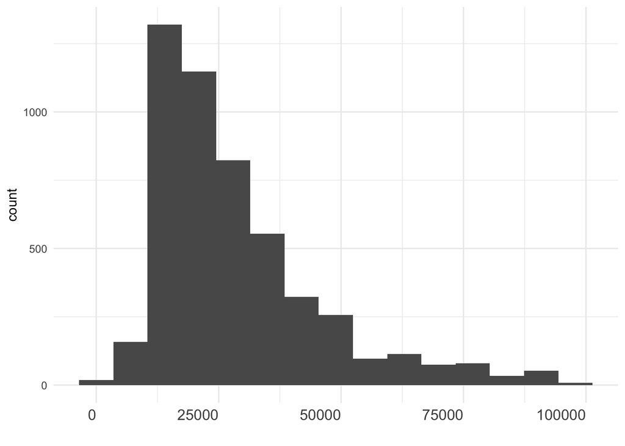

### Age

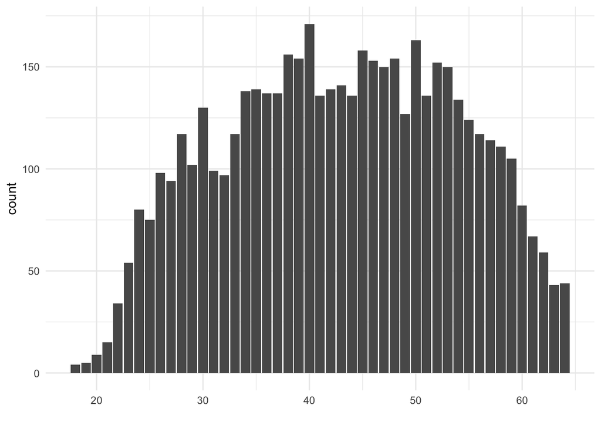

### Hours worked

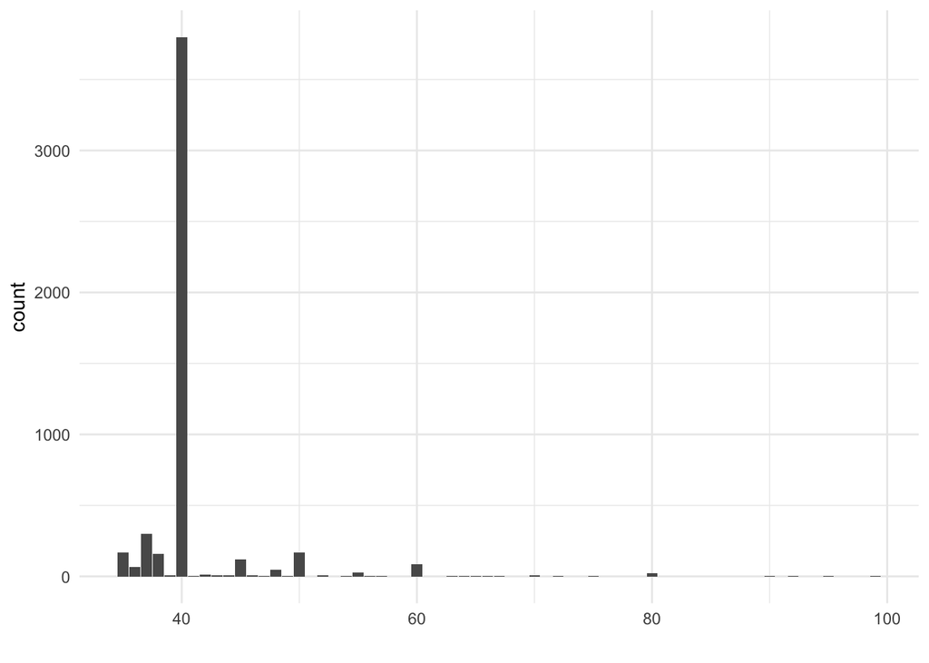

## Task 4:

Generate and examine bar charts/graphs for qualitative variables of interest

### Race

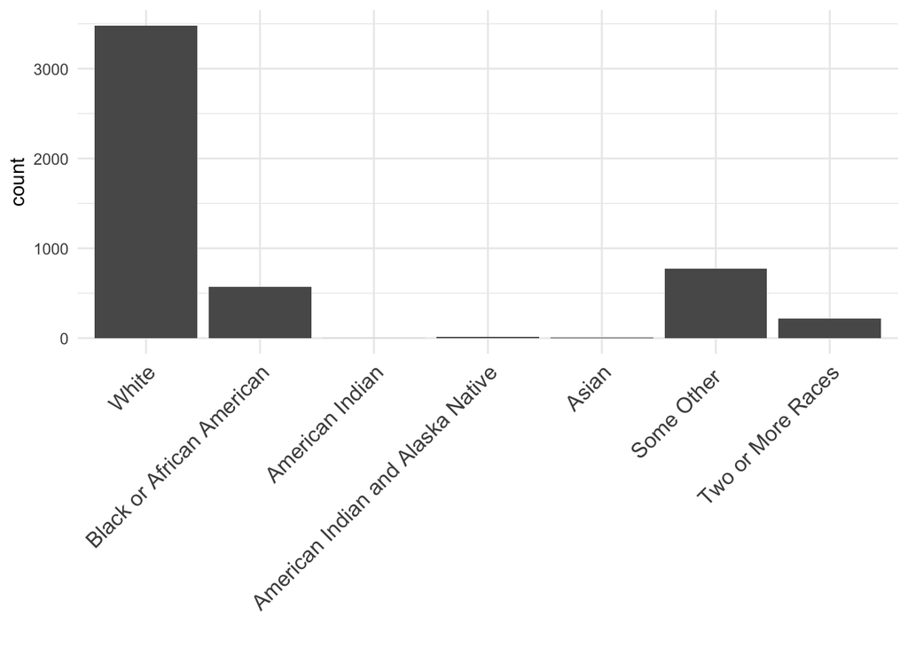

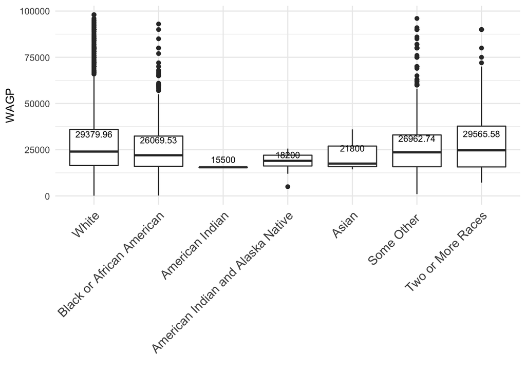

### Race: White

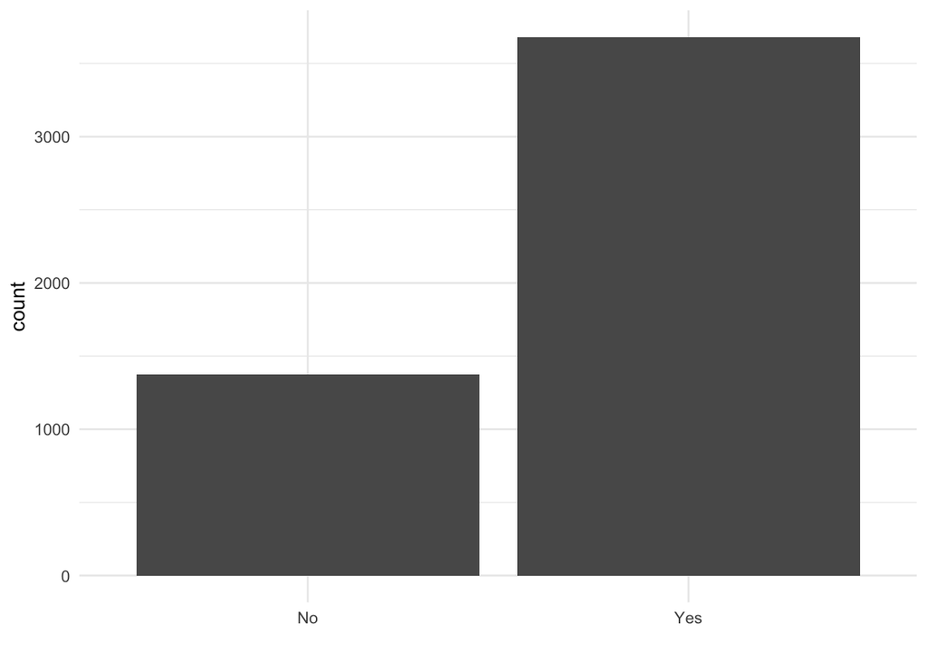

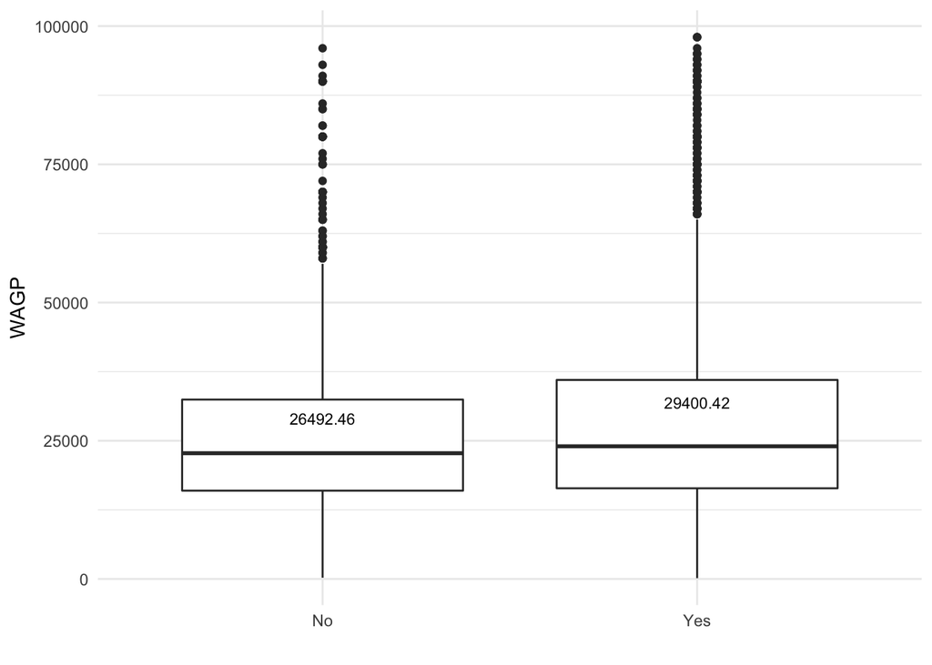

### Race: Black

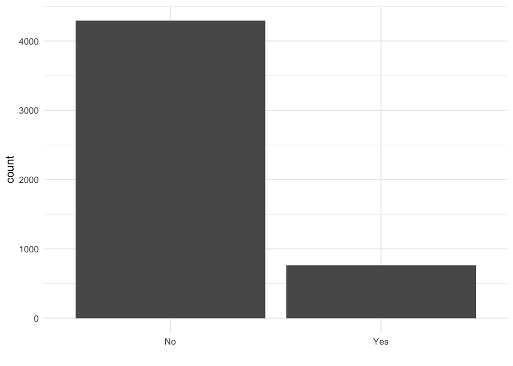

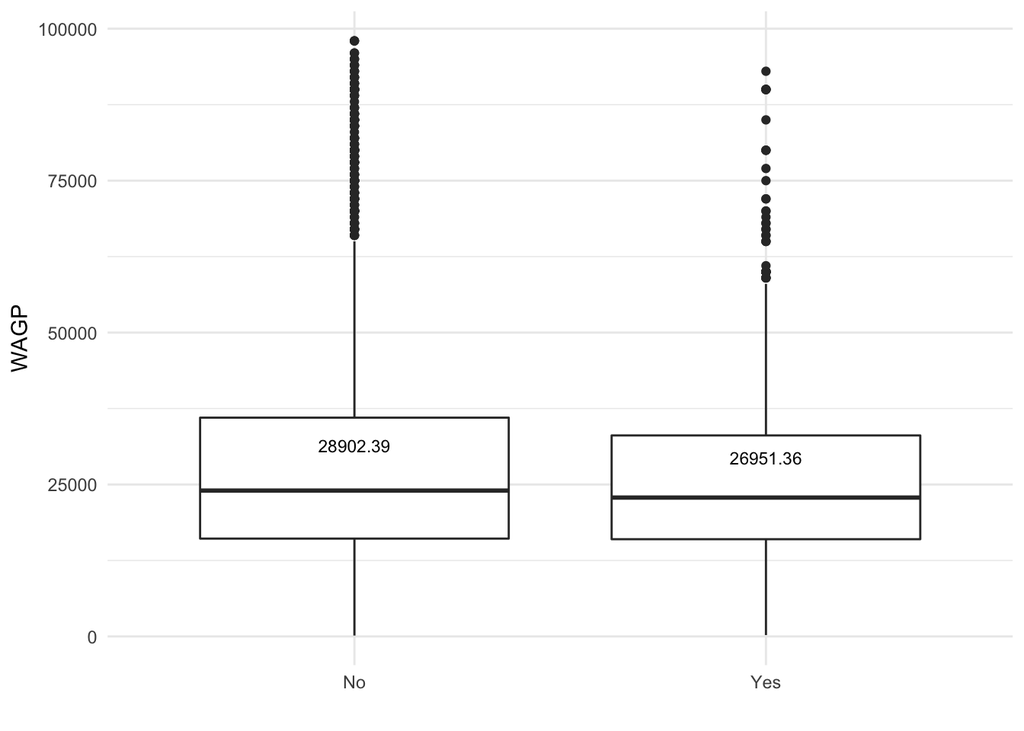

### Race: Other

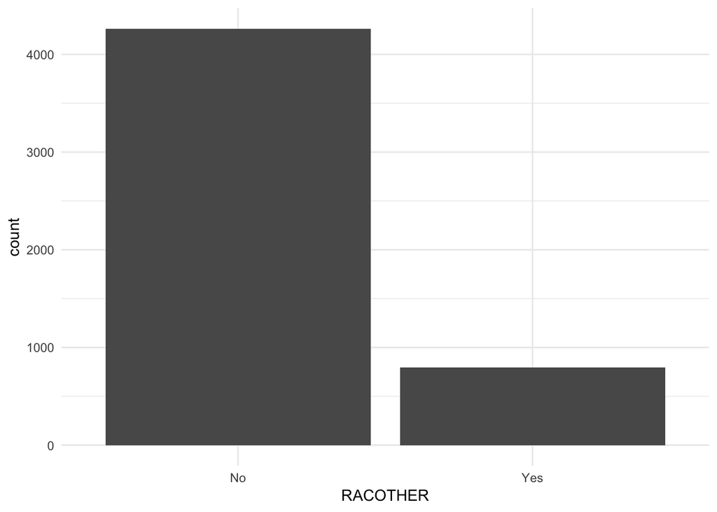

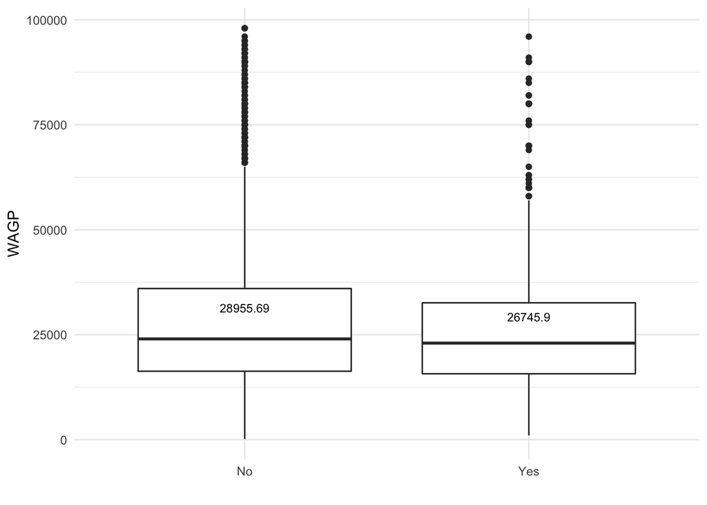

### Ethnicity: Hispanic

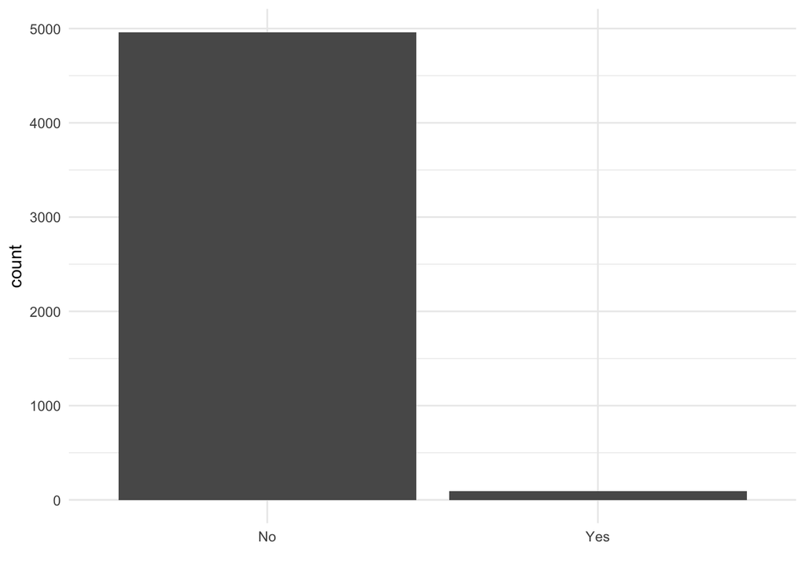

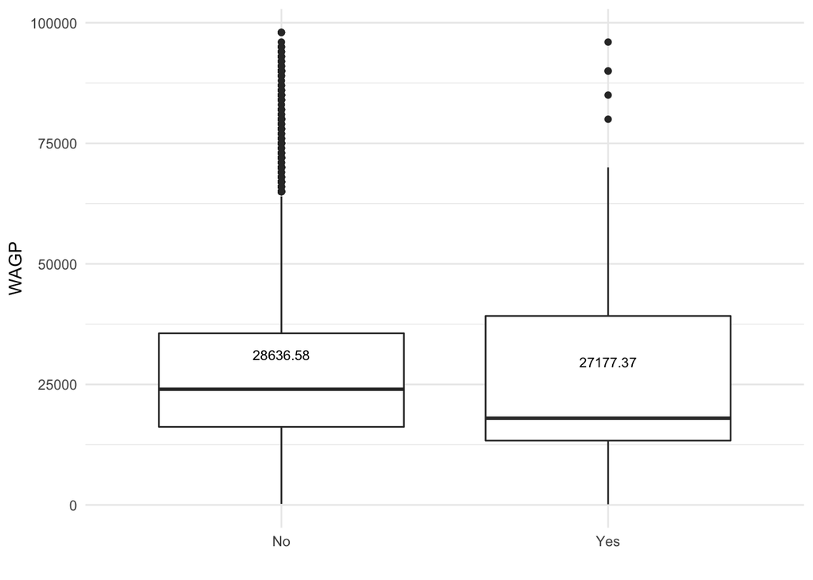

### Marital Status

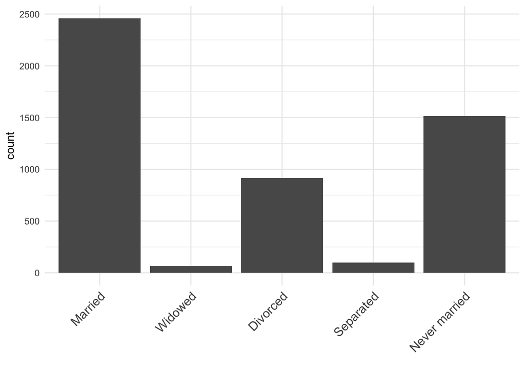

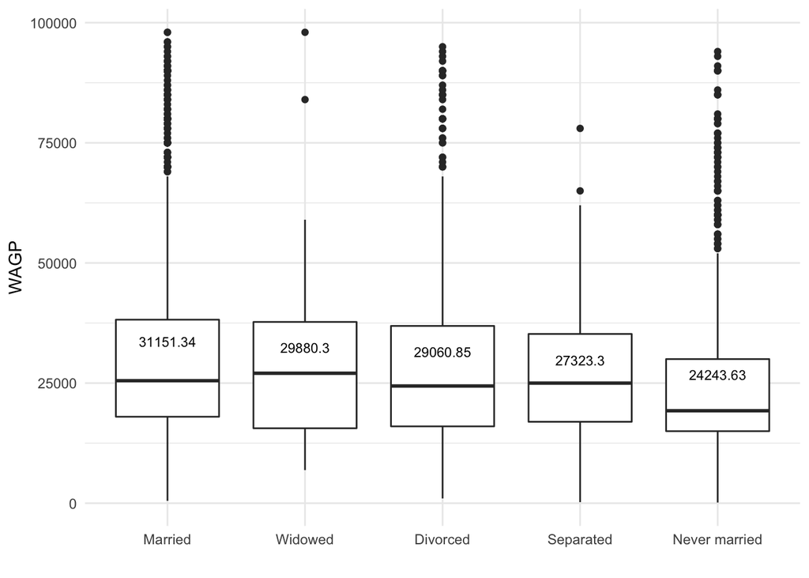

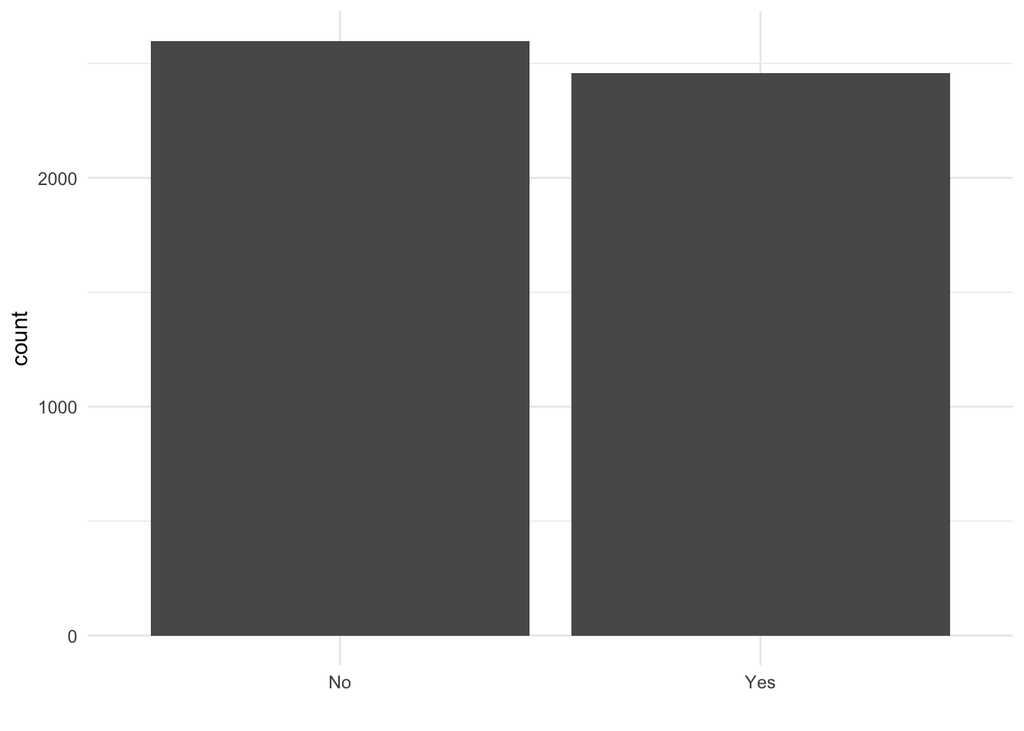

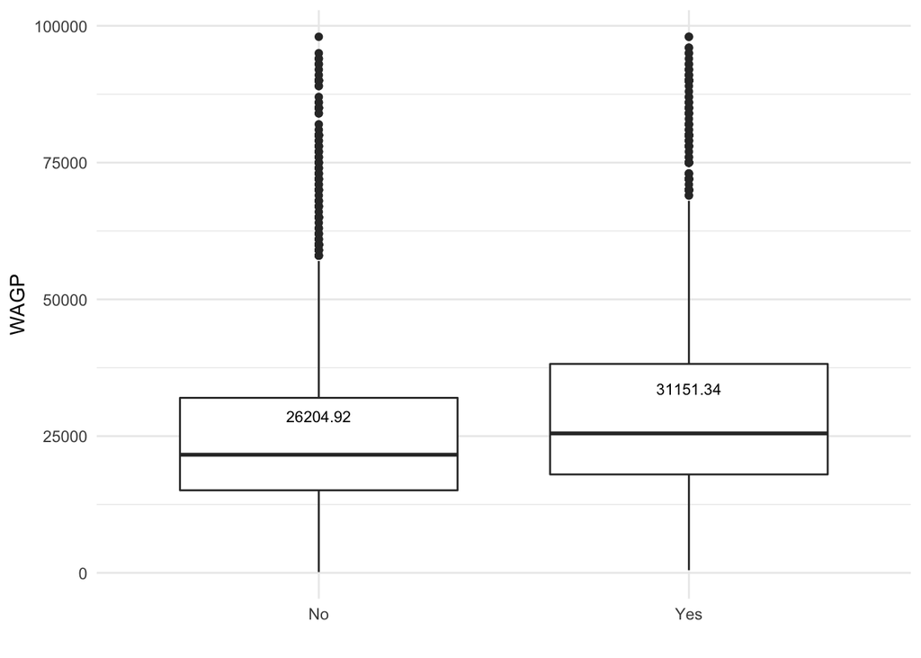

### Ability to speak English

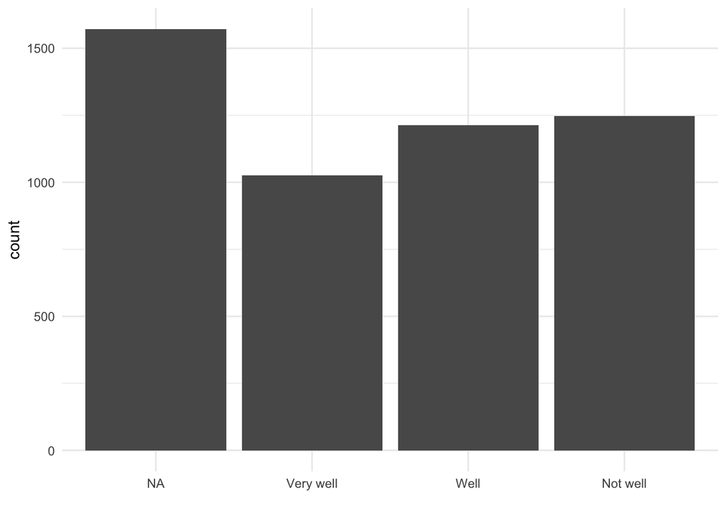

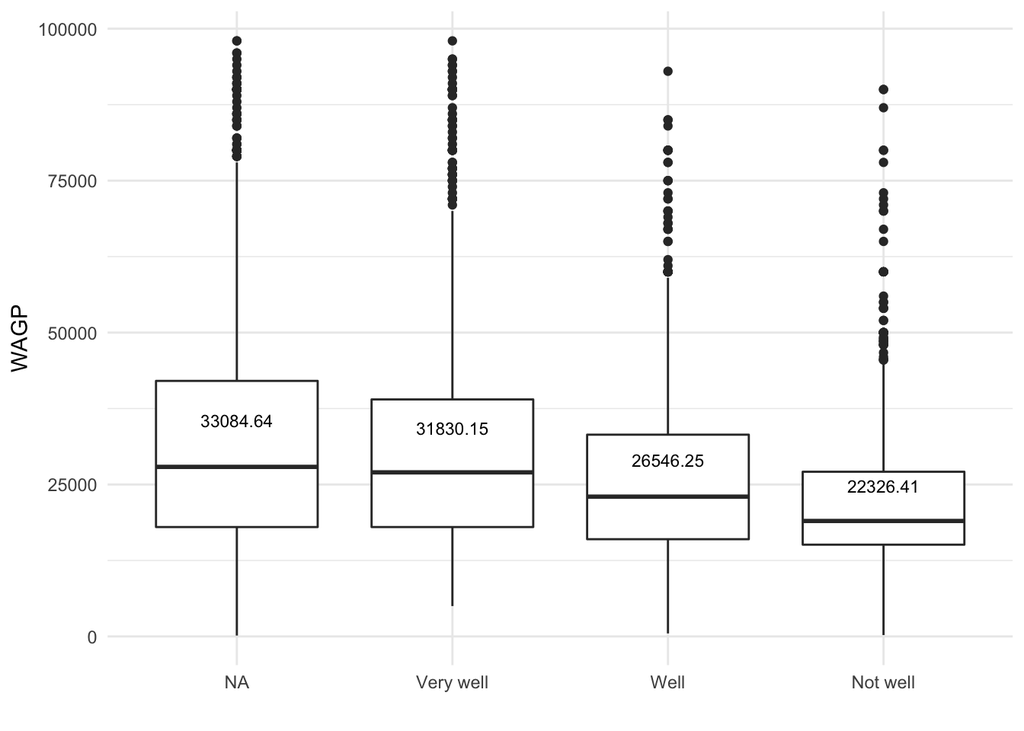

### Educational attainment

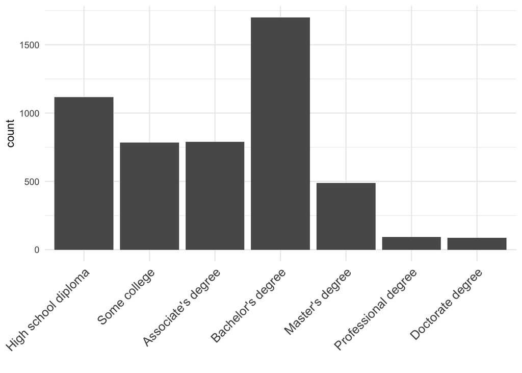

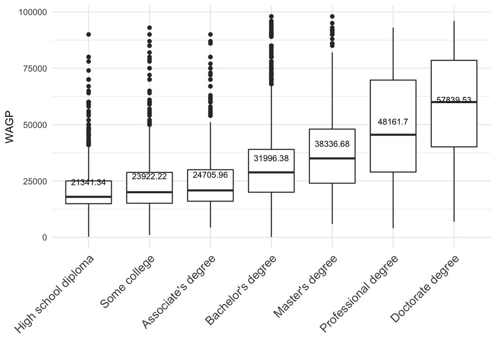

### Sex

Gender is nearly equalized in Puerto Rico

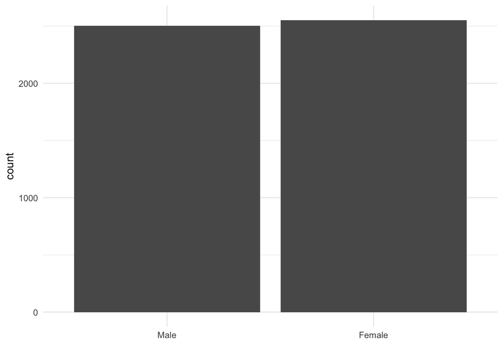

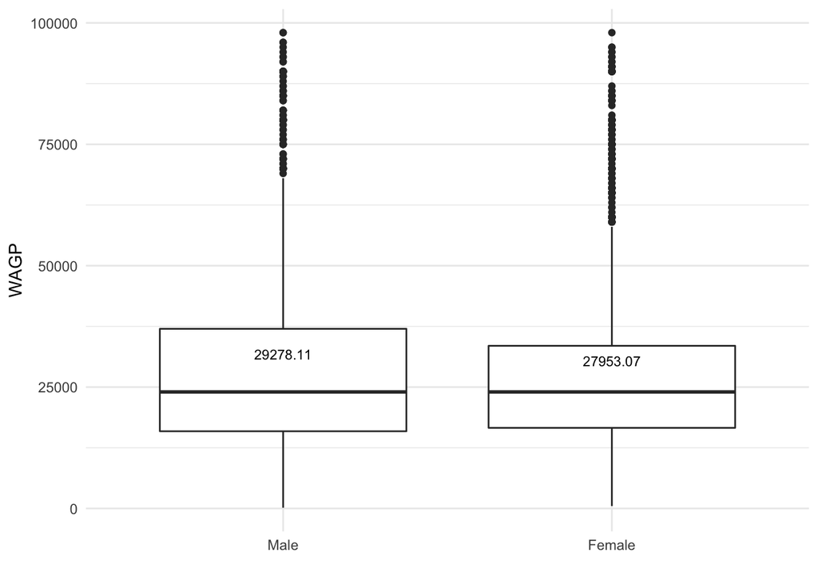

### Work week

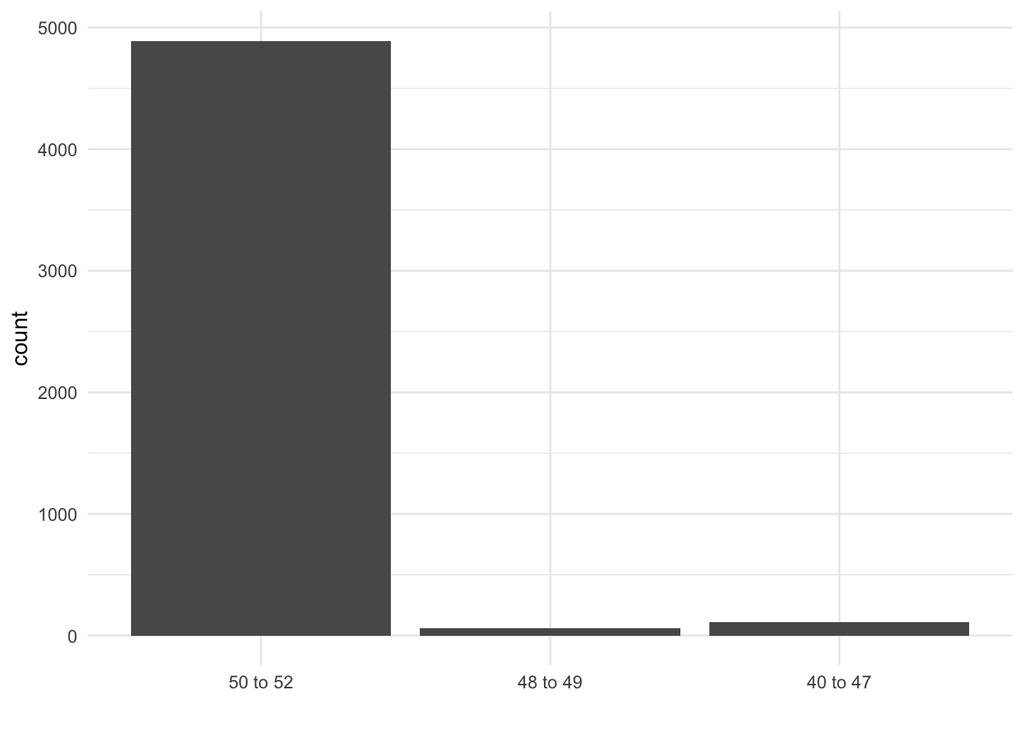

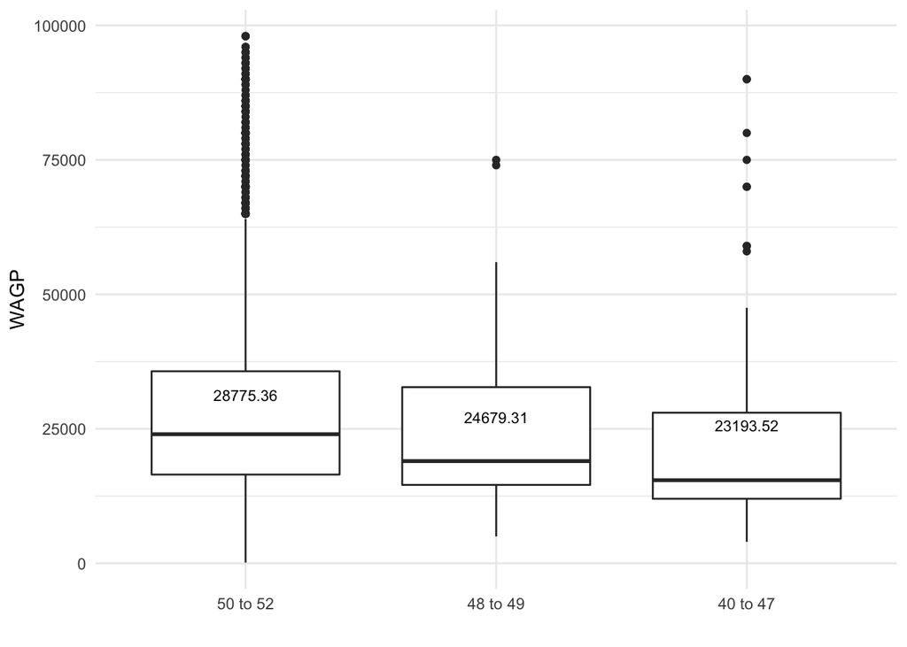

Task 5:

Generate and examine cross tabulations, scatterplots, and/or correlation coefficients of interest

### Age vs. Wage

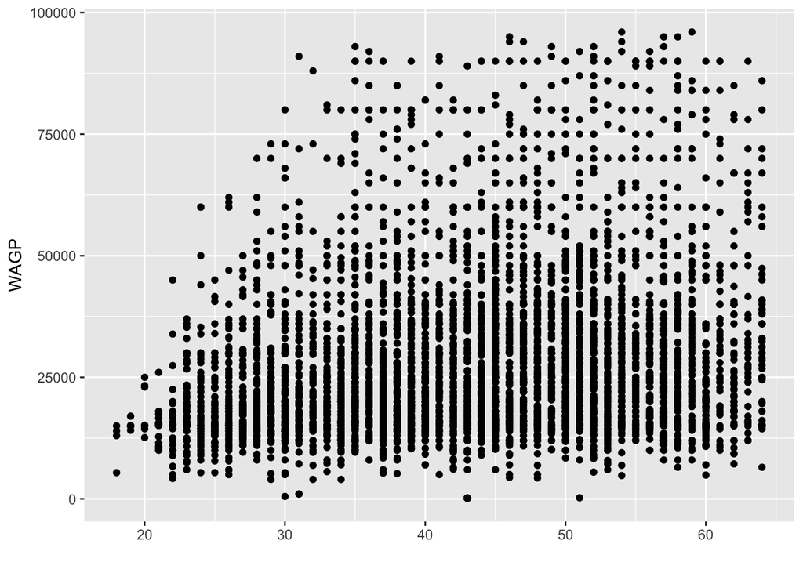

The correlation of 0.23 for age and earnings indicates a very weak relationship. Age is neither a primary reason for differences in earnings, nor a clear proxy for some other variable.

### Work hours vs. Wage

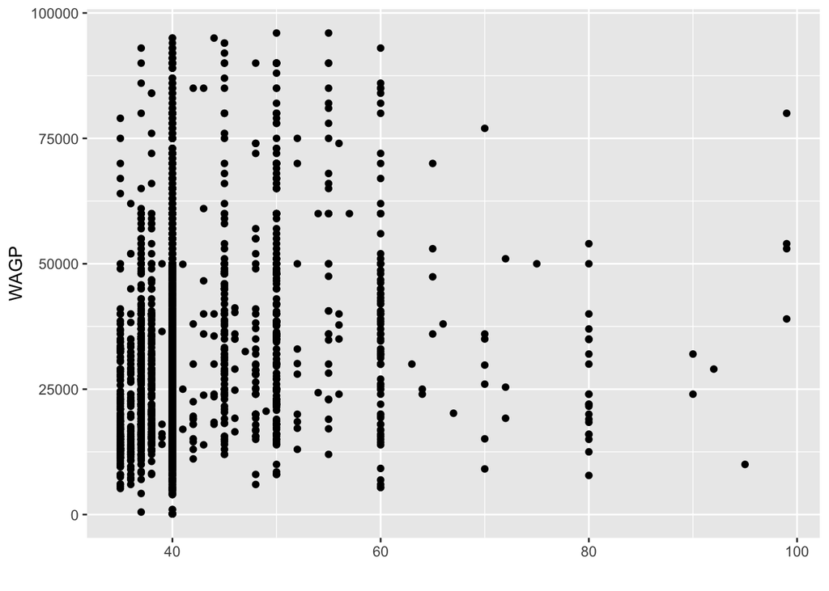

The correlation of 0.18 for earnings and work hours is also very weak. No doubt it would be strong if the data were not filtered to those working more than 35 hours per week. Interestingly, earnings appear to drop for those working more than 60 hours per week.

### Ethinicity: Hispanic

|  | RACHISP: No (N = 4,959) | RACHISP: Yes (N = 95) |
| --- | --- | --- |
| Minimum | 230 | 150 |
| Maximum | 96000 | 96000 |
| Median | 24000 | 18000 |
| Mean | 28594.62 | 27177.37 |

### Race: White

|  | RACWHT: No (N = 1,376) | RACWHT: Yes (N = 3,678) |
| --- | --- | --- |
| Minimum | 230 | 150 |
| Maximum | 96000 | 96000 |
| Median | 22750 | 24000 |
| Mean | 26492.46 | 29344.47 |

### Race: Black

|  | RACBLK: No (N = 4,294) | RACBLK: Yes (N = 760) |
| --- | --- | --- |
| Minimum | 150 | 230 |
| Maximum | 96000 | 93000 |
| Median | 24000 | 22850 |
| Mean | 28854.11 | 26951.36 |

### Race: Other

|  | RACOTHER: No (N = 4,261) | RACOTHER: Yes (N = 793) |
| --- | --- | --- |
| Minimum | 150 | 1000 |
| Maximum | 96000 | 96000 |
| Median | 24000 | 23000 |
| Mean | 28907.08 | 26745.90 |

### Marital Status

|  | MAR1: No (N = 2,598) | MAR1: Yes (N = 2,456) |
| --- | --- | --- |
| Minimum | 150 | 500 |
| Maximum | 95000 | 96000 |
| Median | 21600 | 25450 |
| Mean | 26177.28 | 31096.91 |

### Educational attainment

|  | SCHL: High school diploma (N = 1,116) | SCHL: Some college (N = 783) | SCHL: Associate’s degree (N = 789) | SCHL: Bachelor’s degree (N = 1,699) | SCHL: Master’s degree (N = 487) | SCHL: Professional degree (N = 94) | SCHL: Doctorate degree (N = 86) |
| --- | --- | --- | --- | --- | --- | --- | --- |
| Minimum | 230 | 1000 | 4300 | 150 | 5900 | 4000 | 6900 |
| Maximum | 90000 | 93000 | 90000 | 96000 | 95000 | 93000 | 96000 |
| Median | 17950 | 20000 | 20800 | 28800 | 35000 | 45500 | 60000 |
| Mean | 21341.34 | 23922.22 | 24705.96 | 31918.69 | 38214.17 | 48161.70 | 57839.53 |